# week7final

2025-11-18

```r
#data <- read.csv("mergeddata.csv")
data <- read.csv("/Users/blubb/Desktop/170 files/mergeddata.csv")

set.seed(58)    #seed 58
n <- nrow(data)
train_index <- sample(1:n, size = 0.7 * n)
train_data <- data[train_index, ]
test_data  <- data[-train_index, ]

model1 <- lm(totalDisasters ~ PPM + aveMonthSeaTemp  + avg_surfacePressure+avg_saePressure+ Anomaly+ avg_cng_sealevel, data = train_data)
summary(model1)
```

```
##
## Call:
## lm(formula = totalDisasters ~ PPM + aveMonthSeaTemp + avg_surfacePressure +
##     avg_saePressure + Anomaly + avg_cng_sealevel, data = train_data)
##
## Residuals:
##     Min      1Q  Median      3Q     Max
## -24.610  -7.020  -0.913   6.112  33.971
##
## Coefficients:
##                       Estimate Std. Error t value Pr(>|t|)
## (Intercept)         -1.797e+03  1.036e+03  -1.733   0.0843 .
## PPM                  5.533e-02  7.498e-02   0.738   0.4613
## aveMonthSeaTemp      2.312e+01  3.695e+00   6.257 1.82e-09 ***
## avg_surfacePressure  2.125e-01  4.082e-02   5.204 4.21e-07 ***
## avg_saePressure     -1.886e-01  3.866e-02  -4.879 1.96e-06 ***
## Anomaly             -4.643e+00  2.249e+00  -2.064   0.0401 *
## avg_cng_sealevel    -3.628e-02  3.420e-02  -1.061   0.2898
## ---
## Signif. codes:  0 '***' 0.001 '**' 0.01 '*' 0.05 '.' 0.1 ' ' 1
##
## Residual standard error: 10.52 on 237 degrees of freedom
## Multiple R-squared:  0.1857, Adjusted R-squared:  0.1651
## F-statistic: 9.009 on 6 and 237 DF,  p-value: 7.14e-09
```

I can see that everything is significant except for PPM and avg_cng_sealevel.The R^2 is low however the overall model is still very significant.

```r
cor(train_data[, c("totalDisasters", "PPM", "aveMonthSeaTemp", "avg_saePressure", "Anomaly", "avg_cng_sealevel")])
```

```
##                  totalDisasters          PPM aveMonthSeaTemp avg_saePressure
## totalDisasters       1.00000000  0.127632053       0.2879689    -0.040225073
## PPM                  0.12763205  1.000000000       0.4776240    -0.004642744
## aveMonthSeaTemp      0.28796894  0.477624005       1.0000000    -0.159686543
## avg_saePressure     -0.04022507 -0.004642744      -0.1596865     1.000000000
## Anomaly              0.04693063  0.728772691       0.3763499    -0.036140976
## avg_cng_sealevel     0.14236974  0.717795111       0.4145218    -0.370253752
##                      Anomaly avg_cng_sealevel
## totalDisasters    0.04693063        0.1423697
## PPM               0.72877269        0.7177951
## aveMonthSeaTemp   0.37634987        0.4145218
## avg_saePressure  -0.03614098       -0.3702538
## Anomaly           1.00000000        0.5498622
## avg_cng_sealevel  0.54986221        1.0000000
```

```r
car::vif(model1)
```

```
##                 PPM     aveMonthSeaTemp avg_surfacePressure     avg_saePressure
##            3.810622            1.683985           19.308211           20.729259
##             Anomaly    avg_cng_sealevel
##            2.181840            3.336576
```

```r
modelTesting <- lm(totalDisasters ~ PPM + aveMonthSeaTemp +avg_saePressure+ Anomaly+ avg_cng_sealevel + I(PPM^2) + I(aveMonthSeaTemp^2) + I(avg_saePressure^2) + I(Anomaly^2) + I(avg_cng_sealevel^2), data = train_data)

summary(modelTesting)
```

```
##
## Call:
## lm(formula = totalDisasters ~ PPM + aveMonthSeaTemp + avg_saePressure +
##     Anomaly + avg_cng_sealevel + I(PPM^2) + I(aveMonthSeaTemp^2) +
##     I(avg_saePressure^2) + I(Anomaly^2) + I(avg_cng_sealevel^2),
##     data = train_data)
##
## Residuals:
##     Min      1Q  Median      3Q     Max
## -26.960  -7.254  -1.377   5.798  32.056
##
## Coefficients:
##                         Estimate Std. Error t value Pr(>|t|)
## (Intercept)            9.568e+05  8.174e+05   1.171  0.24298
## PPM                    5.851e+00  2.084e+00   2.808  0.00541 **
## aveMonthSeaTemp        8.371e+01  2.797e+02   0.299  0.76499
## avg_saePressure       -1.898e+01  1.619e+01  -1.172  0.24223
## Anomaly                8.388e-01  5.968e+00   0.141  0.88834
## avg_cng_sealevel       1.377e-01  4.155e-02   3.315  0.00106 **
## I(PPM^2)              -7.568e-03  2.694e-03  -2.809  0.00540 **
## I(aveMonthSeaTemp^2)  -2.481e+00  9.986e+00  -0.248  0.80402
## I(avg_saePressure^2)   9.399e-05  8.018e-05   1.172  0.24231
## I(Anomaly^2)          -1.784e+00  2.579e+00  -0.692  0.48985
## I(avg_cng_sealevel^2) -1.859e-03  4.694e-04  -3.961 9.93e-05 ***
## ---
## Signif. codes:  0 '***' 0.001 '**' 0.01 '*' 0.05 '.' 0.1 ' ' 1
##
## Residual standard error: 10.33 on 233 degrees of freedom
## Multiple R-squared:  0.2283, Adjusted R-squared:  0.1952
## F-statistic: 6.893 on 10 and 233 DF,  p-value: 1.975e-09
```

```r
car::vif(modelTesting, type = 'predictor')
```

```
## GVIFs computed for predictors
```

```
##                      GVIF Df GVIF^(1/(2*Df))        Interacts With
## PPM              5.463909  2        1.528889              I(PPM^2)
## aveMonthSeaTemp  1.786542  2        1.156121  I(aveMonthSeaTemp^2)
## avg_saePressure  1.560756  2        1.117722  I(avg_saePressure^2)
## Anomaly          3.191093  2        1.336549          I(Anomaly^2)
## avg_cng_sealevel 3.698954  2        1.386819 I(avg_cng_sealevel^2)
##                                                             Other Predictors
## PPM              aveMonthSeaTemp, avg_saePressure, Anomaly, avg_cng_sealevel
## aveMonthSeaTemp              PPM, avg_saePressure, Anomaly, avg_cng_sealevel
## avg_saePressure              PPM, aveMonthSeaTemp, Anomaly, avg_cng_sealevel
## Anomaly              PPM, aveMonthSeaTemp, avg_saePressure, avg_cng_sealevel
## avg_cng_sealevel              PPM, aveMonthSeaTemp, avg_saePressure, Anomaly
```

```r
#second round of testing
modelTesting2 <- lm(totalDisasters ~ PPM + aveMonthSeaTemp +avg_saePressure+ Anomaly+ avg_cng_sealevel + PPM*avg_cng_sealevel + PPM*avg_saePressure + PPM*Anomaly + PPM*aveMonthSeaTemp + avg_cng_sealevel*aveMonthSeaTemp, data = train_data)

summary(modelTesting2)
```

```
##
## Call:
## lm(formula = totalDisasters ~ PPM + aveMonthSeaTemp + avg_saePressure +
##     Anomaly + avg_cng_sealevel + PPM * avg_cng_sealevel + PPM *
##     avg_saePressure + PPM * Anomaly + PPM * aveMonthSeaTemp +
##     avg_cng_sealevel * aveMonthSeaTemp, data = train_data)
##
## Residuals:
##     Min      1Q  Median      3Q     Max
## -25.767  -7.620  -1.030   5.548  33.376
##
## Coefficients:
##                                    Estimate Std. Error t value Pr(>|t|)
## (Intercept)                      -2.290e+04  2.210e+04  -1.036   0.3012
## PPM                               5.933e+01  5.760e+01   1.030   0.3041
## aveMonthSeaTemp                  -2.579e+01  1.259e+02  -0.205   0.8379
## avg_saePressure                   2.297e-01  2.201e-01   1.044   0.2977
## Anomaly                           6.160e+01  4.363e+01   1.412   0.1593
## avg_cng_sealevel                  4.211e+00  2.522e+00   1.670   0.0963 .
## PPM:avg_cng_sealevel             -3.974e-03  1.660e-03  -2.394   0.0175 *
## PPM:avg_saePressure              -6.020e-04  5.735e-04  -1.050   0.2950
## PPM:Anomaly                      -1.715e-01  1.137e-01  -1.508   0.1329
## PPM:aveMonthSeaTemp               1.256e-01  3.435e-01   0.366   0.7150
## aveMonthSeaTemp:avg_cng_sealevel -1.899e-01  1.976e-01  -0.961   0.3375
## ---
## Signif. codes:  0 '***' 0.001 '**' 0.01 '*' 0.05 '.' 0.1 ' ' 1
##
## Residual standard error: 10.62 on 233 degrees of freedom
## Multiple R-squared:  0.1844, Adjusted R-squared:  0.1494
## F-statistic: 5.269 on 10 and 233 DF,  p-value: 5.476e-07
```

```r
car::vif(modelTesting2, type = 'predictor')
```

```
## GVIFs computed for predictors
```

```
##                        GVIF Df GVIF^(1/(2*Df))
## PPM                    1.00 10        1.000000
## aveMonthSeaTemp  5702892.74  6        3.656015
## avg_saePressure    25938.72  3        5.440742
## Anomaly          4048845.17  3       12.624723
## avg_cng_sealevel 5702892.74  6        3.656015
##                                                               Interacts With
## PPM              avg_cng_sealevel, avg_saePressure, Anomaly, aveMonthSeaTemp
## aveMonthSeaTemp                                        PPM, avg_cng_sealevel
## avg_saePressure                                                          PPM
## Anomaly                                                                  PPM
## avg_cng_sealevel                                        PPM, aveMonthSeaTemp
##                                                    Other Predictors
## PPM                                                            --
## aveMonthSeaTemp                            avg_saePressure, Anomaly
## avg_saePressure          aveMonthSeaTemp, Anomaly, avg_cng_sealevel
## Anomaly          aveMonthSeaTemp, avg_saePressure, avg_cng_sealevel
## avg_cng_sealevel                           avg_saePressure, Anomaly
```

I can see that I(avg_cng_sealevel^2) and I(PPM^2) are significant and increased the R^2 a good amount. I also see that PPM * avg_cng_sealevel is significant. I will apply these changes to model 2.

```r
model2 <- lm(totalDisasters ~ PPM + aveMonthSeaTemp +avg_saePressure+ Anomaly+ avg_cng_sealevel + I(PPM^2) + I(avg_cng_sealevel^2) + PPM * avg_cng_sealevel, data = train_data)

summary(model2)
```

```
##
## Call:
## lm(formula = totalDisasters ~ PPM + aveMonthSeaTemp + avg_saePressure +
##     Anomaly + avg_cng_sealevel + I(PPM^2) + I(avg_cng_sealevel^2) +
##     PPM * avg_cng_sealevel, data = train_data)
##
## Residuals:
##     Min      1Q  Median      3Q     Max
## -27.752  -7.156  -1.292   6.128  28.918
##
## Coefficients:
##                         Estimate Std. Error t value Pr(>|t|)
## (Intercept)           -3.030e+03  1.070e+03  -2.831  0.00504 **
## PPM                    1.700e+01  3.055e+00   5.563 7.21e-08 ***
## aveMonthSeaTemp        1.111e+01  3.218e+00   3.452  0.00066 ***
## avg_saePressure       -2.813e-03  9.708e-03  -0.290  0.77225
## Anomaly               -1.862e+00  2.166e+00  -0.860  0.39085
## avg_cng_sealevel      -5.876e+00  1.414e+00  -4.156 4.54e-05 ***
## I(PPM^2)              -2.259e-02  4.065e-03  -5.556 7.45e-08 ***
## I(avg_cng_sealevel^2) -6.225e-03  1.130e-03  -5.507 9.52e-08 ***
## PPM:avg_cng_sealevel   1.622e-02  3.813e-03   4.254 3.03e-05 ***
## ---
## Signif. codes:  0 '***' 0.001 '**' 0.01 '*' 0.05 '.' 0.1 ' ' 1
##
## Residual standard error: 9.946 on 235 degrees of freedom
## Multiple R-squared:  0.2783, Adjusted R-squared:  0.2537
## F-statistic: 11.32 on 8 and 235 DF,  p-value: 1.501e-13
```

```r
car::vif(model2, type = "predictor")
```

```
## GVIFs computed for predictors
```

```
##                      GVIF Df GVIF^(1/(2*Df))             Interacts With
## PPM              3.857267  5        1.144532 I(PPM^2), avg_cng_sealevel
## aveMonthSeaTemp  1.428709  1        1.195286                       --
## avg_saePressure  1.461834  1        1.209063                       --
## Anomaly          2.263681  1        1.504553                       --
## avg_cng_sealevel 3.857267  5        1.144532 I(avg_cng_sealevel^2), PPM
##                                                         Other Predictors
## PPM                            aveMonthSeaTemp, avg_saePressure, Anomaly
## aveMonthSeaTemp          PPM, avg_saePressure, Anomaly, avg_cng_sealevel
## avg_saePressure          PPM, aveMonthSeaTemp, Anomaly, avg_cng_sealevel
## Anomaly          PPM, aveMonthSeaTemp, avg_saePressure, avg_cng_sealevel
## avg_cng_sealevel               aveMonthSeaTemp, avg_saePressure, Anomaly
```

I also see that the multicollinearity problem has been solved by making these changes.

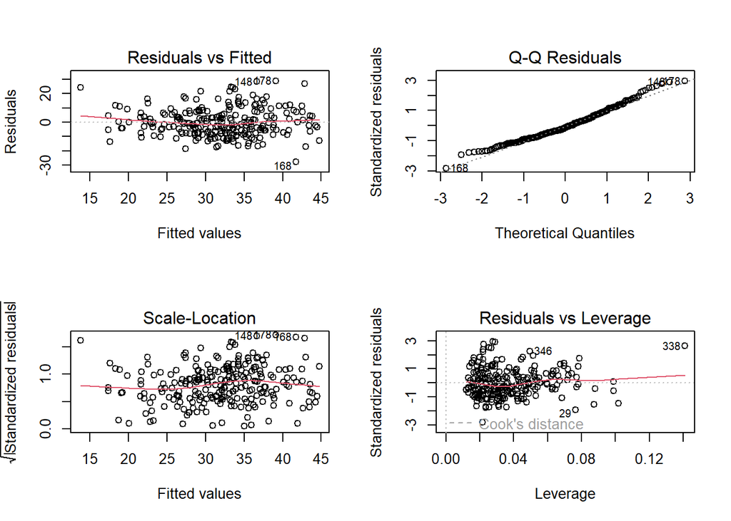

```r
par(mfrow = c(2,2))
plot(model2)
```

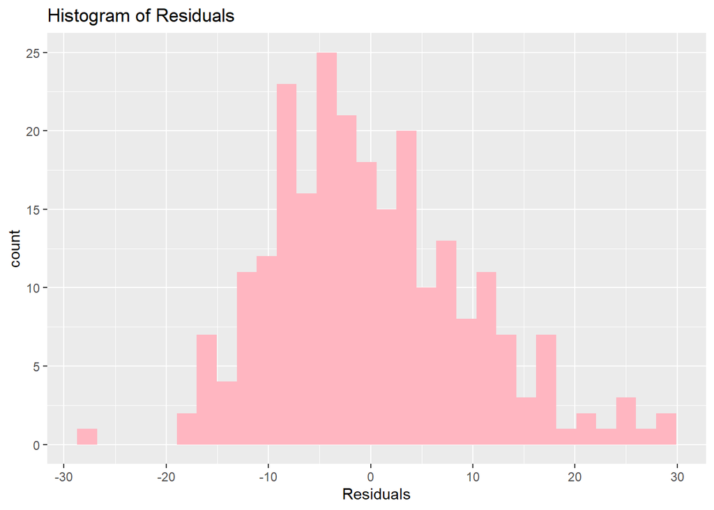

```r
ggplot(data = train_data, aes(x = model2$residuals)) +
    geom_histogram(fill = "lightpink") +
    labs(title = "Histogram of Residuals", x = "Residuals")
```

The histogram of residuals looks pretty normal (maybe the tiniest bit of right skewing) and the scale-location plot also looks pretty normal with no obvious pattern visible meaning the variance should be constant and therefore not have heteroscedasticity. The QQ plot also appears to be pretty well in line with the straight line and there could be potential outliers just looking at the tail of the plot, there’s a few points that stray away but nothing extreme. The residuals vs fitted plot does not show any obvious pattern of curving or u shapes so we can assume this is a linear pattern.

```r
pred_test <- predict(model2, newdata = test_data)
RMSE <- sqrt(mean((test_data$totalDisasters - pred_test)^2))
RMSE
```

```
## [1] 9.846085
```

```r
testR2 <- cor(test_data$totalDisasters, pred_test)^2
testR2
```

```
## [1] 0.2858493
```

The R^2 I got from model2 is almost the same as the one from the test data meaning that there shouldn’t be much over or underfitting. The RMSE seems a little high but probably not enough to be a concern.